# 11章 空間構造のある階層ベイズモデル

nonsabotage

2018-12-30

```
全体ではばらついているけれど, 「近所」では似ているというのが
空間相関のある場所差です. 事前分布を工夫して, このような場所差を
入れた階層ベイズモデルを作ってみましょう.
```

# はじめに

- 10章では場所差が独立に決まるというモデルを考えた
- 実際には場所差が独立に決まるデータ構造とは限らない
- **空間相関** を考慮したモデルを考えるには?

$$p(y_i|\lambda_i) = \frac{\lambda_i}{y_i!}\exp(-\lambda_i)$$

$$\log \lambda_i = \beta_1 + \beta_2f_i + r_i + r_{j(i)}$$

$$p(r_j|s)=\frac{1}{\sqrt{2\pi s^2}}\exp\left\{-\frac{r_i^2}{2s^2}\right\}$$

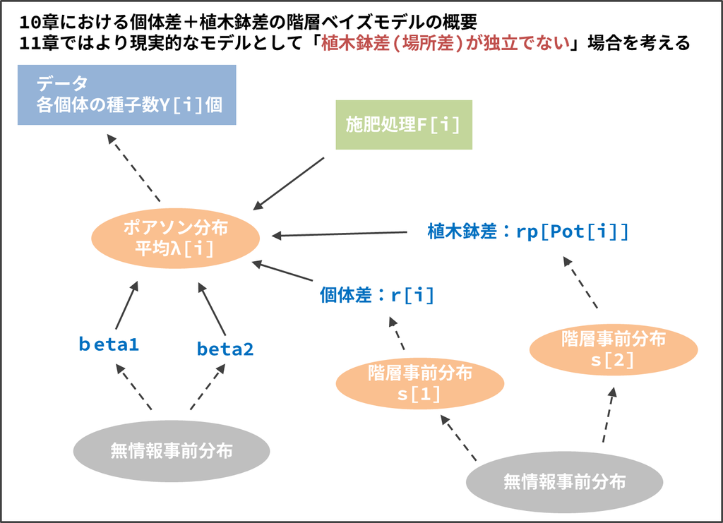

# 例題：一次元空間上の個体数分布

空間モデリング例として仮想データ「1本の直線上に等間隔に配置されている調査区画で, ある生物の個体数」を考える.

- $j$ :調査区画番号$1, 2, ..., 50$
- $y_j$ :調査区画 $j$ で観測された個体数. ポアソン分布から発生
- 局所密度 :調査区画におけるポアソンの平均値

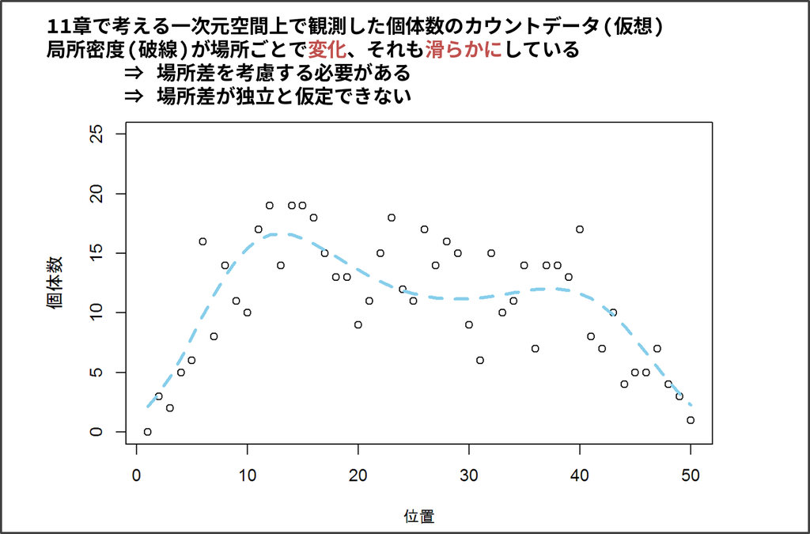

## 階層ベイズモデルに空間構造を組み込む

10章まで同様に観測データ$\{ y_i \}$が従う確率分布から, 順にモデルを構築していく.

観測データは, 上限のないカウントデータのため, ポアソン分布を仮定する.

$$p(y_i|\lambda) = \frac{\lambda}{y_i!}\exp(-\lambda)$$

### 単純なポアソンモデル

- 場所差がなく, すべてのデータが平均値 $\lambda$ のポアソン分布だと仮定
- **過分散** が生じる
  - データの分散が27.4
  - ポアソン分布を仮定した分散の推定値は10.9

### 場所差を組み込んだポアソンモデル

- 過分散に対応する => 場所差を組み込んだモデルを作成

$$\log \lambda_j = \beta + r_j$$

- $\lambda_j$ : 場所$j$における局所密度(平均値)
- $\beta$ : すべてのデータで共通の大域的パラメータ
- $r_j$ : 場所$j$にのみ効果を与える局所的パラメータ

### 空間構造のない階層事前分布

- 場所差$r_j$の事前分布を使い空間構造を制御
- 10章のような式を指定すると場所差$r_i$が独立になる

$$p(r_j|s)=\frac{1}{\sqrt{2\pi s^2}}\exp\left\{-\frac{r_i^2}{2s^2}\right\}$$

### 空間構造のある階層事前分布

- 空間構造をどのような仮定で、表現するかは「**モデル設計者が考える**」
- 緑本では次の三つを仮定
  - 近傍から受ける影響の重みは, 等しく$\frac{1}{n_j}$
  - 近傍とは隣接する場所を指す
  - 階層事前分布を次式で考える

$$p(r_j|u_j, s) = \sqrt{\frac{n_j}{2\pi s^2}}\exp\left\{-\frac{(r_j-\mu_j)^2}{2\frac{s^2}{n_j}}\right\}$$

$$\mu_j = \frac{r_{j-1} + r_{j+1}}{2}$$

- $r_j$が従う分布の平均値は, $r_{j-1}$と$r_{j+1}$の平均値
- $r_j$が従う分布の分散は$s^2/n_j$なので近傍数$n_j$が多いほど分散が小さい

### 条件付き自己回帰

- 上記のような事前分布を **条件付き自己回帰** と呼ぶ
  - conditional auto regressive, CAR
- 結局のところ場所差$\{r_i\}$の事前分布は次式となる.

$$p(\{r_i\}|s)\propto \exp\left\{-\frac{1}{2s^2}\sum_{j\sim\prime{j}}(r_j-r_{\prime{j}})^2\right\}$$

## 空間データを当てはめる

ここまでで設定した事後分布は以下となる.

$$p(\beta,s,\{r_j\}|Y)\propto p(\{r_j\}|s)p(s)p(\beta)\Pi_jp(y_j|\lambda_j)$$

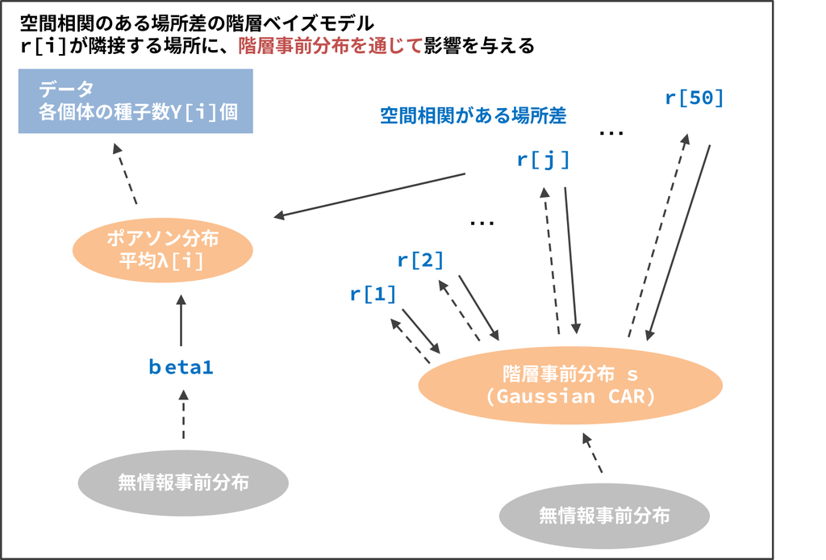

- $\{ r_j \}$ のような相互作用する確率変数の場を **確率場** という
- stanで計算
- 緑本に比べてなめらか過ぎる..
- コードはこちらのブログを参考にするとほんと同じになりました[久保緑本11章のマルコフ場モデル（空間構造のあるベイズモデル）](http://statmodeling.hatenablog.com/entry/markov-field-model)
  - なぜ異なってしまったのかは後ほど..
- 階層事前分布がなにを表現しているかは[この動画を参照](https://www.youtube.com/watch?v=M7rN6paP99g)

### ばらつきパラメータが確率場に与える影響

階層事前分布の分散を制御している$s$と関係を見る. 大きなイメージとしては, $s$を大きくする⇒$r_j$がとれる範囲が大きくなる, 「近隣と似ている」を表現していない。

次の図は$\beta$を2．27に固定したうえで, $s$を.03, 3, 10と変化させたときにどのような$r_j$が サンプルリングされているかを確認する.

$s$が大きくなるとギザギザになる, つまり滑らかな変化を表現できない.

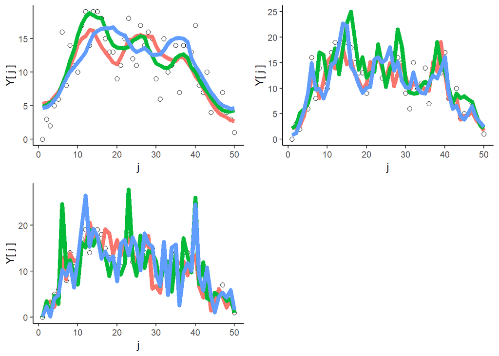

```r
grid.arrange(

    base + geom_line(data=ggs1, size=2, aes(x, value, group=Iteration, color=as.factor(Iteration))) + guides(color=FALSE),
    base + geom_line(data=ggs2, size=2, aes(x, value, group=Iteration, color=as.factor(Iteration))) + guides(color=FALSE),
    base + geom_line(data=ggs3, size=2, aes(x, value, group=Iteration, color=as.factor(Iteration))) + guides(color=FALSE),
    nrow=2, ncol=2
)
```

## 空間相関モデルと欠測のある観測データ

### 空間相関を組み込んだ階層ベイズモデルの強み

- 欠測のあるデータに対してよりよい予測
- 11章の事前分布と、10章の事前分布の場合とで異なる結果
- 図の黒丸が欠測させた値
  - 11章の事前分布を使った左側の図の方がなめらかになっている

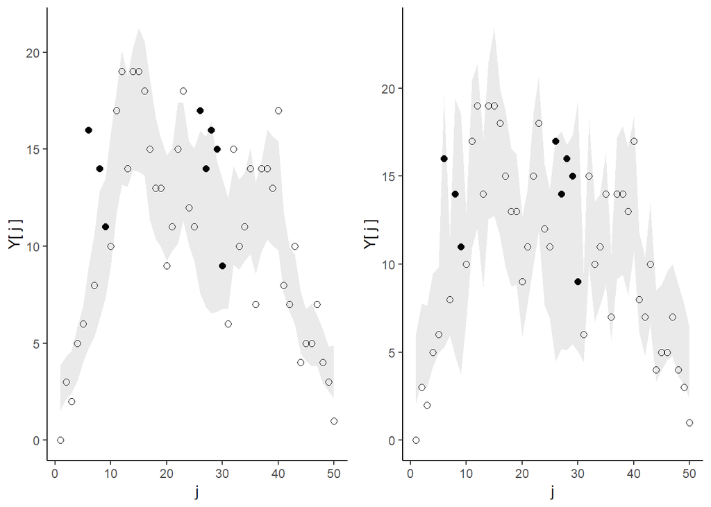

```r
grid.arrange(

    base + geom_ribbon(data=ggs1, mapping=aes(x=x, ymin=q05, ymax=q95), alpha=.1),
    base + geom_ribbon(data=ggs2, mapping=aes(x=x, ymin=q05, ymax=q95), alpha=.1),
    ncol=2

)
```

## 補足：緑本よりも予測が滑らかだった理由

- p.246 ~ p.247に記述してある$p(r_j|\mu_j)$と, $p(\{r_j\}|s)$の違いがわかってなかった
  - $p(\{r_j\}|s)$は1階差分式
  - 緑本の結果は1階差分式の場合
  - $p(r_j|\mu_j)$は2階差分式
  - 2階の方が滑らか
  - $p(r_j|\mu_j)$に対してフルコンディションから導出

$p(\{r_j\}|s)$で$j$に着目すると, …1階差分であることがわかる.

$$\propto \exp\left\{C[(r_j-r_{j-1})^2+(r_j-r_{j+1})^2]\right\}$$

上の式で$p(r_j|r_{j-1})$を考えると, …二回差分が導出される.

$$\propto \exp\left\{C[2r_i^2-2r_j(r_{j-1}+r_{j+1}) + r_{j-1}^2+r_{j+1}^2]\right\}$$

$p(r_j|r_{j-1})$では$r_j$以外は定数なのに注意して, 平方完成する.

$$\propto \exp\left\{C[r_i^2-r_j(r_{j-1}+r_{j+1})]\right\}\\
\propto \exp\left\{C[r_i-\frac{1}{2}(r_{j-1}+r_{j+1})]^2\right\}\\
\propto \exp\left\{C[(r_{j+1}-r_{j})-(r_{j}-r_{j-1})]^2\right\}$$